# week2

### Unordered lists

- first
- second

### Ordered lists

1. First
2. Third
3. Second

Doesn’t matter which order you lay them out

### Syntax

#### Links

[RStudio](http://www.rstudio.com/)

#### Advance Links

I spend so much time reading [Simply Statistics](http://www.google.com/)!

Here’s an inline link to [Google](http://www.google.com/). Here’s a reference-style link to [Google](http://www.google.com/). Here’s a very readable link to [Yahoo!](http://www.yahoo.com/).

Here’s a [poorly-named link](http://www.google.com/). Never write “[click here][^1]”. Visit [us](http://stackoverflow.com/).

#### New lines

two spaces create a new line

### What is markdown?

- you can concentrate on the content
- r markdown is markdown for r, we’ll use knitr

```r
library(datasets)
summary(airquality)
```

```
##      Ozone           Solar.R           Wind             Temp
##  Min.   :  1.00   Min.   :  7.0   Min.   : 1.700   Min.   :56.00
##  1st Qu.: 18.00   1st Qu.:115.8   1st Qu.: 7.400   1st Qu.:72.00
##  Median : 31.50   Median :205.0   Median : 9.700   Median :79.00
##  Mean   : 42.13   Mean   :185.9   Mean   : 9.958   Mean   :77.88
##  3rd Qu.: 63.25   3rd Qu.:258.8   3rd Qu.:11.500   3rd Qu.:85.00
##  Max.   :168.00   Max.   :334.0   Max.   :20.700   Max.   :97.00
##  NA's   :37       NA's   :7
##      Month            Day
##  Min.   :5.000   Min.   : 1.0
##  1st Qu.:6.000   1st Qu.: 8.0
##  Median :7.000   Median :16.0
##  Mean   :6.993   Mean   :15.8
##  3rd Qu.:8.000   3rd Qu.:23.0
##  Max.   :9.000   Max.   :31.0
##
```

Let’s make a plot of the data

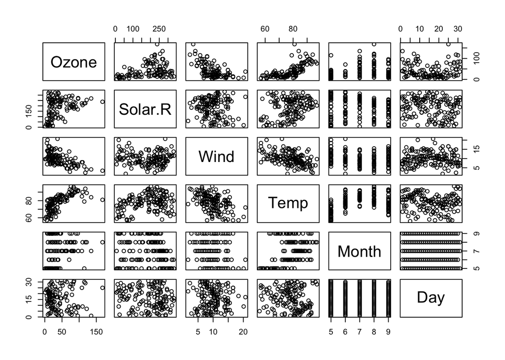

```r
plot(airquality)
```

Here’s a regression model of ozone, wind, solar radiation, and temperature

```r
library(stats)
fit <- lm(Ozone ~ Wind + Solar.R + Temp, data = airquality)
summary(fit)
```

```
##
## Call:
## lm(formula = Ozone ~ Wind + Solar.R + Temp, data = airquality)
##
## Residuals:
##     Min      1Q  Median      3Q     Max
## -40.485 -14.219  -3.551  10.097  95.619
##
## Coefficients:
##              Estimate Std. Error t value Pr(>|t|)
## (Intercept) -64.34208   23.05472  -2.791  0.00623 **
## Wind         -3.33359    0.65441  -5.094 1.52e-06 ***
## Solar.R       0.05982    0.02319   2.580  0.01124 *
## Temp          1.65209    0.25353   6.516 2.42e-09 ***
## ---
## Signif. codes:  0 '***' 0.001 '**' 0.01 '*' 0.05 '.' 0.1 ' ' 1
##
## Residual standard error: 21.18 on 107 degrees of freedom
##   (42 observations deleted due to missingness)
## Multiple R-squared:  0.6059, Adjusted R-squared:  0.5948
## F-statistic: 54.83 on 3 and 107 DF,  p-value: < 2.2e-16
```

### Literate programming

knitr is good for most things, but not for long/specific documents

#### complicated way of knitting

```r
library(knitr)
setwd("/Users//shota/git//Coursera-Data-Science/Reproducible research/")
knit2html("week2.Rmd")
browseURL("week2.html")
```

the produced markdown document includes the result in the console

#### Inline text computations

The current time is 土 3 21 23時03分54秒 2015. My favorite random number is -0.6203667.

#### Incorporating graphics

```r
x <- rnorm(100)
y <- x + rnorm(100, sd=0.5)
```

Here’s the scatter plot

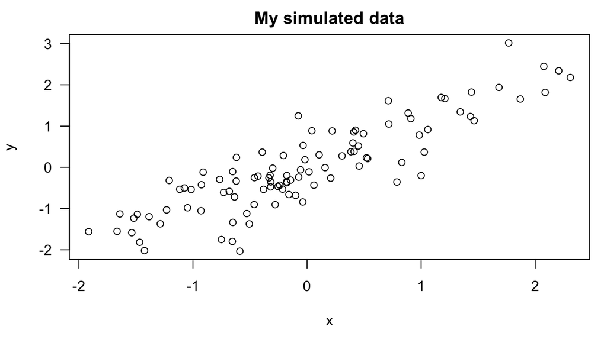

```r
par(mar=c(5,4,2,1), las=1)
plot(x, y, main = "My simulated data")
```

### Making tables

```r
library(datasets)
data(airquality)
fit <- lm(Ozone ~ Wind + Temp + Solar.R, data = airquality)
```

Here is a table of regression coefficients

```r
library(xtable)
xt <- xtable(summary(fit))
print(xt, type = "html")
```

|  | Estimate | Std. Error | t value | Pr(>\|t\|) |
| --- | --- | --- | --- | --- |
| (Intercept) | -64.3421 | 23.0547 | -2.79 | 0.0062 |
| Wind | -3.3336 | 0.6544 | -5.09 | 0.0000 |
| Temp | 1.6521 | 0.2535 | 6.52 | 0.0000 |
| Solar.R | 0.0598 | 0.0232 | 2.58 | 0.0112 |

### Setting Global options

First simulated data

```r
x <- rnorm(100)
y <- x + rnorm(100, sd=0.5)
```

Here’s the scatterplot

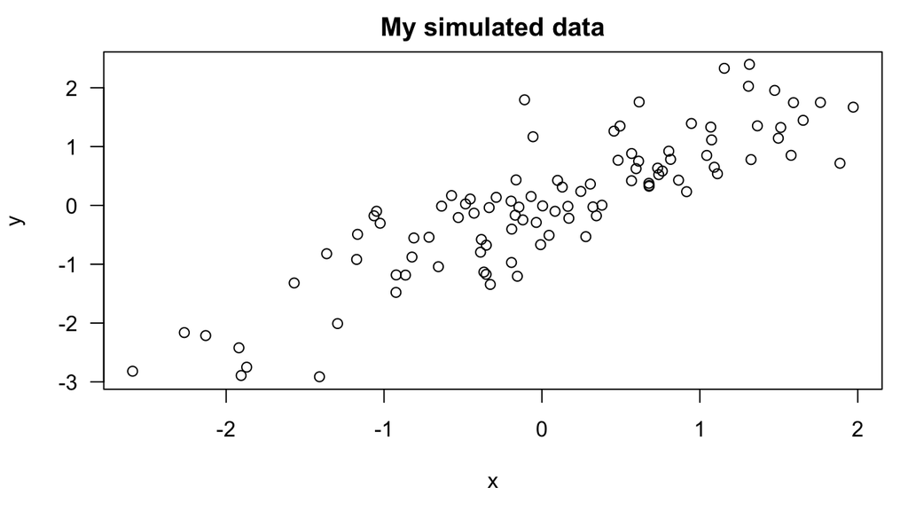

[^1]: http://www.w3.org/QA/Tips/noClickHere (Advice against the phrase “click here”)